# Изменение импеданса сборок TEPC-2–TEPC-7 и ТТРКГ при динамике сердца по 4D-КТ Nix

**Статус: вычислительный пилот на автоматических масках. Независимая анатомическая и физическая валидация не выполнена.**

Цель опыта — получить сопоставимые кривые изменения импеданса семи заданных электродных сборок при пофазном изменении анатомической маски сердца. Этот расчёт выполняет первые два этапа плана 40.19: проверку координат и построение общего анатомического ориентира. Приоритет здесь имеет непосредственно рассчитанное изменение сигнала, а не производная в одной центральной точке.

**Главное ограничение:** маски доходят до верхней границы поля обзора 4D-КТ. Поэтому моделируется наблюдаемая часть автоматической маски. Динамика за пределами поля обзора неизвестна и не достраивается. Само касание границы не определяет, какая именно сердечная или сосудистая структура обрезана; для этого нужен отдельный анатомический разбор. Полученный сигнал нельзя считать подтверждённым сигналом полного сердца.

## Исходные данные и совмещение

Использованы 12 масок TotalSegmentator v2 одного участника и существующая статическая модель его грудной клетки, построенная методом конечных элементов (FEM). Использована независимая маска целого органа из задачи total; она не получена объединением масок камер и миокарда. Маски являются вычислительным анатомическим ориентиром; их точность относительно независимой разметки пока неизвестна. Все 12 состояний данного пилота относятся к разработке методики и не являются отложенной проверочной выборкой для будущей настройки модели. Объём этой маски не равен объёму отдельной камеры или ударному объёму.

**Что именно изменяется в модели.** В расчёт передана маска целого сердца, а не только крови в камерах. Вся область внутри её границы имеет одну постоянную проводимость эффективного сердечного материала. Отдельные свойства крови и миокарда, объёмы камер и внутренние границы стенок в прямой задаче не заданы. Поэтому перераспределение крови и миокарда при неизменной наружной границе не изменило бы результат этой модели. Рассчитанные кривые отражают пофазное изменение наружной геометрии наблюдаемой сердечной области. Для оценки пригодности такого упрощения необходимо отдельное сравнение с моделью, в которой кровь камер и миокард представлены разными материалами.

Статическая и динамическая серии имеют одинаковый идентификатор системы координат пациента. Координаты NIfTI RAS преобразованы в координаты FEM изменением знаков x и y и переводом миллиметров в метры. Для всех фаз применено одно преобразование; отдельная подгонка сердца каждой фазы не выполнялась. По общим костным поверхностям медиана расстояния составила 0,79 мм, 95-й процентиль — 4,39 мм. По внешней поверхности тела в общей центральной области соответствующие значения составили 0,56 и 1,41 мм. Это поддерживает прямой перенос координат для пилота, но не определяет независимую погрешность регистрации. Расстояния включают различия сегментации и дискретизации поверхностей.

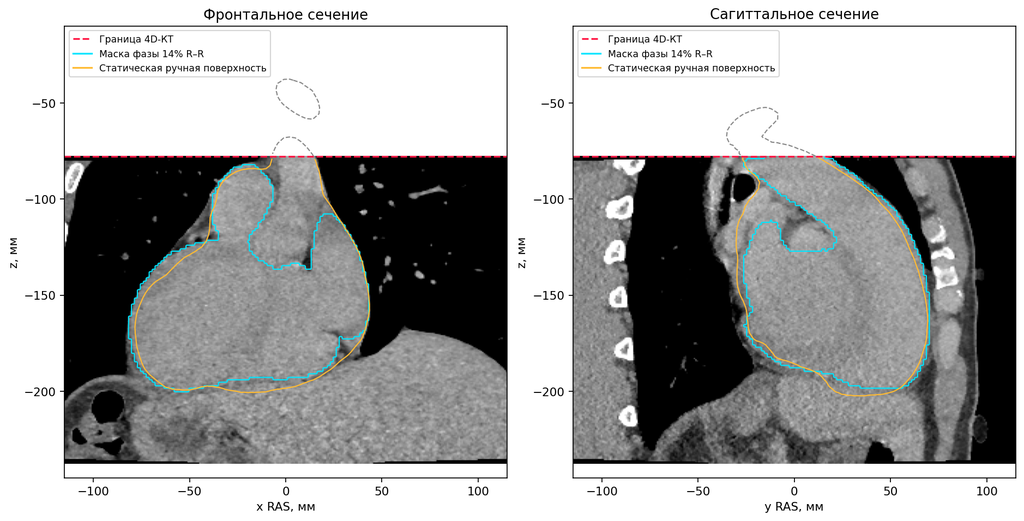

**Рисунок 1.** Фазовая маска на КТ и сечение статической ручной поверхности сердца в общей системе координат. Красная линия обозначает верхнюю границу динамической серии. Серый пунктир выше неё показывает только продолжение статической поверхности за пределами обзора; анатомическое соответствие этой части по 4D-КТ не проверяется. Различие контуров включает различия фазы, поля обзора и способов сегментации. Совпадение центра сердца специально не навязывалось: такая подгонка могла бы скрыть искомое перемещение.

## Временная привязка и определение одного цикла

Исходные метки фаз: 14, 23, 33, 43, 53, 62, 72, 82, 92, 101, 111, 121% R–R. Метки выше 100% относятся к следующему интервалу. Длительность первого интервала по существующей ЭКГ-привязке равна 822,0 мс, следующего — 787,0 мс. Время между точками восстановлено по исходным меткам и длительностям соответствующих R–R. Основной график охватывает окно длительностью первого интервала от первой доступной фазы. Точки сохраняют исходный порядок и время; последняя и первая точки искусственно не приравниваются. Начало полного интервала от R-зубца до 14% отсутствует, поэтому окно длиной R–R не следует считать полностью наблюдённым циклом между двумя R-зубцами. Перенос фаз следующего сокращения в начало первого потребовал бы отдельного допущения о повторяемости. Соединяющие отрезки служат только для чтения графика. Значение на границе окна между двумя рассчитанными фазами не является отдельным решением FEM.

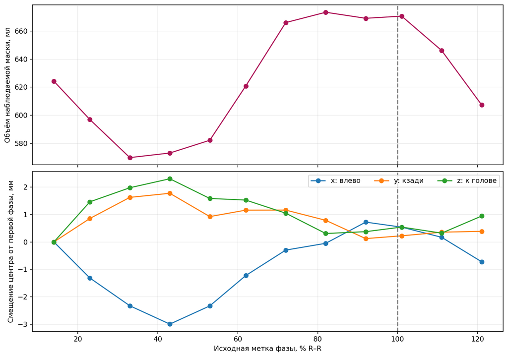

**Рисунок 2.** Изменение объёма наблюдаемой маски и координат её объёмного центра. Во всех доступных фазах объём лежит в диапазоне 569,852–673,371 мл. Размахи координат x, y, z составляют соответственно 3,717; 1,773; 2,303 мм. Эти величины характеризуют данную автоматическую сегментацию. Они содержат как возможные реальные изменения анатомии, так и вариабельность границ маски; эти составляющие ещё не разделены.

## Электрическая модель и заданные сборки

Расчёт выполнен на одной сетке: 791 141 узел и 4 448 426 тетраэдров. Используется квазистатическая резистивная модель на частоте 50 кГц; ёмкостная составляющая не моделируется. Электроды представлены полной моделью конечного контакта (CEM), номинальный диаметр диска — 5 мм. Удельный контактный импеданс принят равным 0,000159155 Ом·м². Эти параметры и сопротивления тканей — условия модели, а не индивидуальные измерения.

Исходное сердце заменено мягкими тканями, а лёгкие и кости сохранены. Каждая фазовая маска накладывается заново на этот неподвижный фон. Внутри маски назначаются свойства эффективного сердца, после её ухода восстанавливается фоновый материал. Неизвестная сердечная область за пределами 4D-КТ не сохраняется в качестве придуманной динамической части. Поэтому абсолютный импеданс также зависит от принятого ограничения поля обзора. Вычитание опорного Z не гарантирует устранения этой ошибки: исключение сердечной или сосудистой области за пределами обзора меняет распределение тока и тем самым может изменить отклик на движение оставшейся области.

| Ткань | ρ, Ом·м |
| --- | --- |
| Мягкие ткани | 12,975453 |
| Лёгкие | 6,779277 |
| Эффективное сердце | 3,271862 |
| Кости | 48,445126 |

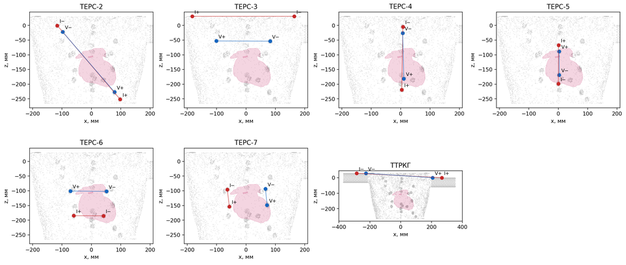

| Сборка | Фактические площади I+, V+, V−, I−, мм² |
| --- | --- |
| TEPC-2 | 20,092; 20,155; 19,753; 19,852 |
| TEPC-3 | 19,692; 19,825; 19,763; 19,672 |
| TEPC-4 | 19,734; 19,661; 19,756; 19,752 |
| TEPC-5 | 19,738; 19,694; 19,664; 19,803 |
| TEPC-6 | 19,838; 19,707; 19,688; 19,740 |
| TEPC-7 | 19,644; 19,716; 19,748; 19,698 |
| ТТРКГ | 19,881; 19,881; 20,380; 19,883 |

**Рисунок 3.** Фактические расчётные центры электродов в проекции на фронтальную плоскость. Красным показана токовая пара I+/I−, синим — измерительная V+/V−, розовым — проекция маски первой фазы. Линии соединяют пары условно и не обозначают путь тока. Каждая панель соответствует отдельной четырёхэлектродной модели; совместное подключение всех сборок не моделируется.

Для чтения рисунка: TEPC-2 — диагональное расположение; TEPC-3 — верхний поперечный монтаж; TEPC-4 — протяжённый вертикальный монтаж; TEPC-5 — более короткий центральный вертикальный монтаж; TEPC-6 — две горизонтальные пары на разных уровнях; TEPC-7 — две разнесённые вертикальные пары. Дополнительный вариант ТТРКГ — четыре диска на модельных продолжениях рук: измерительные контакты расположены в 20 мм, токовые — в 80 мм от соответствующей границы «туловище–рука». Эти расстояния задают модельный вариант для сопоставления и не подтверждают фактическую установку электродов при регистрации. Контакты ТТРКГ заново построены на той же FEM-сетке; для каждой фазы использованы прежние материальные матрицы и новая контактная матрица. Исходные 72 решения TEPC сохранены без пересчёта; выполнены ещё 12 независимых решений для ТТРКГ.

В каждом тетраэдре рассчитана доля объёма фазовой маски. Для проверки интегрирования использованы вложенные наборы из 4096 и 16 384 точек; в электрический расчёт переданы доли по 16 384 точкам. Для линейных конечных элементов средняя проводимость элемента равна σₑ = (1 − fₑ)σфон,ₑ + fₑσсердце, где fₑ — доля сердечного материала в элементе, σфон,ₑ — проводимость его неизменного фонового материала, σсердце — принятая проводимость эффективного сердца. При этом ρ = 1/σ; усреднение сопротивлений вместо проводимостей не выполняется. Это способ интегрирования материалов внутри конечного элемента, а не новая физиологическая смесь тканей. Материальные матрицы EIDORS собраны заново для каждой фазы. Такое интегрирование уменьшает ступенчатость замены материала, но не уточняет пространственную аппроксимацию электрического поля. У разных сборок использованы свои контактные матрицы и отдельные факторизации системы.

## Изменение импеданса

Передаточный импеданс определён как Z = (U(V+) − U(V−)) / I. Изменение ΔZ = Z(t) − Z(t₀) отсчитывается от первой доступной фазы, соответствующей 14% R–R. Положительное ΔZ означает увеличение передаточного импеданса при зафиксированном порядке электродов. Знаки сохраняются во всех таблицах и рисунках. Размах определяется как максимум минус минимум рассчитанных значений внутри выбранного временного окна.

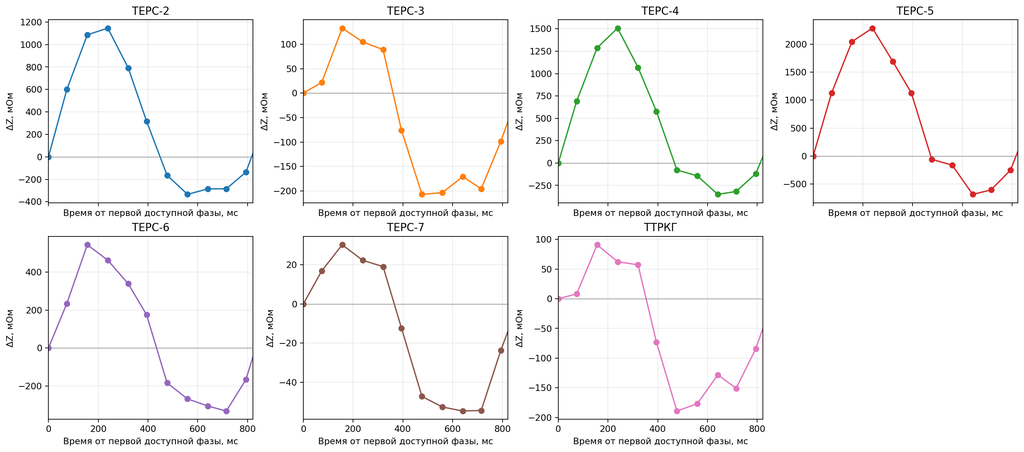

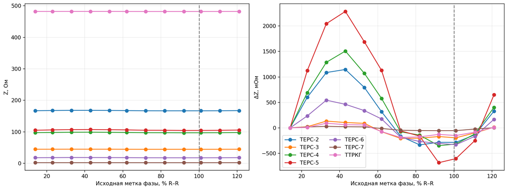

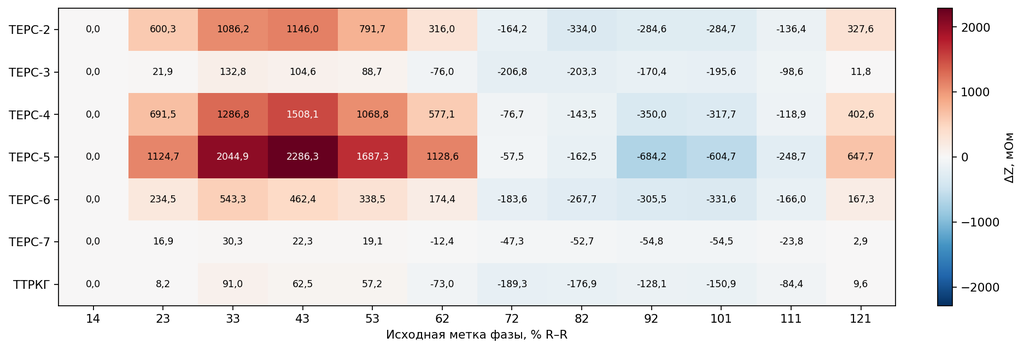

| Сборка | Z опорной фазы, Ом | Размах ΔZ в окне R–R, мОм | Размах / модуль Z опорной фазы, % |
| --- | --- | --- | --- |
| TEPC-2 | 166,965833 | 1480,085 | 0,886 |
| TEPC-3 | 44,598115 | 339,626 | 0,762 |
| TEPC-4 | 97,171644 | 1858,035 | 1,912 |
| TEPC-5 | 104,906739 | 2970,499 | 2,832 |
| TEPC-6 | 17,708580 | 874,848 | 4,940 |
| TEPC-7 | 1,887290 | 85,033 | 4,506 |
| ТТРКГ | 482,175849 | 280,251 | 0,058 |

**Численный результат.** Размахи в окне одного R–R: TEPC-5: 2970,499 мОм; TEPC-4: 1858,035 мОм; TEPC-2: 1480,085 мОм; TEPC-6: 874,848 мОм; TEPC-3: 339,626 мОм; ТТРКГ: 280,251 мОм; TEPC-7: 85,033 мОм. В этом опыте наибольший размах получен для TEPC-5, наименьший — для TEPC-7. Это ранжирование относится к совместному изменению доступной геометрии; оно пока не определяет точность восстановления объёма.

По относительному размаху наибольшее значение имеет TEPC-6 — около 4,94% исходного Z. У TEPC-5 наибольший абсолютный размах, а относительный составляет около 2,83%. Различие связано с нормированием на собственный исходный импеданс каждой сборки. Нормирование меняет порядок сборок и не превращает относительную амплитуду в оценку избирательности.

У дополнительного ТТРКГ исходный импеданс составляет 482,176 Ом, а размах в выбранном окне — 280,251 мОм (0,058%). Этот результат дополнительно показывает, что большой исходный импеданс не гарантирует большого отклика на изменение сердечной области. Он относится к выбранным контактам на модельных руках и к наблюдаемой части маски; перенос на реальную запись ТТРКГ требует отдельной проверки.

Фазы максимумов среди рассчитанных состояний: TEPC-2, TEPC-4, TEPC-5 — 43% R–R; TEPC-3, TEPC-6, TEPC-7, ТТРКГ — 33% R–R. Таким образом, монтаж влияет на форму отклика, а не только на его масштаб. Этот сдвиг относится к дискретным фазам; временное разрешение КТ не позволяет трактовать его как точную физиологическую задержку.

**Рисунки 4–6.** Первый рисунок показывает по одной кривой для каждой сборки в окне длительностью одного R–R; вертикальные шкалы индивидуальны, чтобы сохранить видимость формы каждого сигнала. Второй рисунок показывает все 12 исходных фаз и позволяет сравнить амплитуды по общей шкале. Третий представляет те же изменения цветом: красный — увеличение, синий — уменьшение, белый — значение около опорного. Цветовая шкала едина для всех сборок.

Таблица под рисунками показывает размах среди непосредственно рассчитанных точек, попавших в окно одного R–R. Он может недооценивать истинный размах непрерывной кривой из-за редкой фазовой выборки. Процент относительно исходного Z — относительная амплитуда данного сигнала; он не является производной по объёму или показателем избирательности к сердцу.

## Почему импеданс TEPC-7 меньше, чем TEPC-6

В TEPC-6 токовые электроды расположены поперечной парой, а измерительные — поперечной парой выше них. Каждый измерительный контакт находится примерно в 84–85 мм от ближнего токового и в 139–141 мм от дальнего. В TEPC-7 токовая пара находится с одной стороны груди, а измерительная — с другой: расстояния между измерительными и токовыми контактами составляют 129–145 мм. Это геометрическое различие объясняет, почему измерительные точки TEPC-6 сильнее различаются по потенциалу. В TEPC-7 действие токовых контактов противоположного знака в большей степени компенсируется в области измерительной пары. Расстояния иллюстрируют механизм; точное отношение импедансов получено из неоднородной FEM-модели, а не из одной только геометрической формулы.

Для наглядности решение первой фазы пересчитано к условному току 1 мА. Этот ток выбран для иллюстрации линейного решения и не является установленным током прибора. У TEPC-6 потенциалы измерительных контактов равны −3,304 и −21,013 мВ, их разность — 17,709 мВ. У TEPC-7 соответствующие значения равны −6,185 и −8,073 мВ, а разность — 1,887 мВ. При делении на одинаковый ток получаются 17,709 и 1,887 Ом: различие примерно в 9,4 раза. Потенциалы отсчитаны от принятого расчётного нуля; физически значима их разность, которая не зависит от выбора этого нуля.

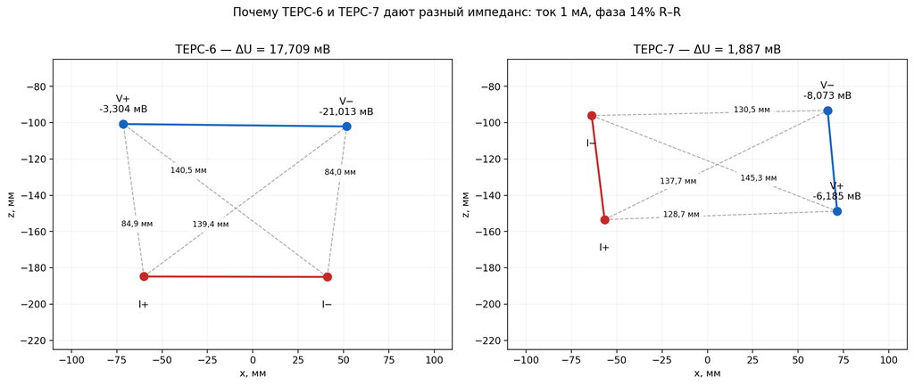

**Рисунок 7.** Сопоставление геометрии и рассчитанных потенциалов TEPC-6 и TEPC-7 в опорной фазе. Показана фронтальная проекция; подписи расстояний относятся к полным трёхмерным расстояниям между центрами. Красная линия связывает токовые контакты, синяя — измерительные; линии не являются траекториями тока. На рисунке видно, что в TEPC-6 измерительные контакты различаются по близости к токовым полюсам; в TEPC-7 оба измерительных контакта удалены от токовой пары.

Порядок контактов TEPC-7 сверён с исходным пользовательским JSON; максимальное смещение центра при построении конечной площадки составляет 0,203 мм. Взаимность и восстановление токов также выполнены. Эти проверки не выявили перестановки ролей или ошибки решения системы, но не заменяют проверку фактической установки электродов и пространственной сходимости.

Малый передаточный импеданс TEPC-7 не означает малого сопротивления всей грудной клетки. В выбранном временном окне размах составляет 0,085 Ом, или 4,51% исходного Z; у TEPC-6 — 0,875 Ом, или 4,94%. Похожие проценты соответствуют существенно различающимся абсолютным сигналам. Для выбора сборки необходимо сопоставлять абсолютный отклик с погрешностью измерения и с влиянием перемещения сердца. Сам по себе большой исходный Z либо большой относительный размах не определяет точность восстановления объёма.

## Проверка расчёта и ограничения интерпретации

Максимальное расхождение объёма маски и её материального представления в FEM составило 0,00441%. Максимальная относительная невязка линейной системы среди 84 решений составила 1.57e-10. Дополнительно проверены восстановление токов на контактах и взаимность передаточного импеданса. При увеличении числа точек интегрирования с 4096 до 16 384 максимальное изменение полного материального объёма составило 0,0508 мл. При этом максимальная сумма абсолютных изменений по отдельным тетраэдрам равна 0,8958 мл. Различие этих двух показателей означает, что локальные ошибки могут компенсироваться в суммарном объёме. Для оценки их влияния на Z требуется отдельный электрический пересчёт. Эти проверки подтверждают согласованность численного решения принятой системы. Они не доказывают её соответствие реальному измеренному сигналу.

| Фаза, % R–R | Объём маски, мл | Объём материала FEM, мл | Расхождение, % | Маска касается границы КТ |
| --- | --- | --- | --- | --- |
| 14 | 624,256 | 624,230 | -0,00405 | да |
| 23 | 596,982 | 596,965 | -0,00292 | да |
| 33 | 569,852 | 569,844 | -0,00128 | да |
| 43 | 573,116 | 573,114 | -0,00027 | да |
| 53 | 582,208 | 582,182 | -0,00441 | да |
| 62 | 620,873 | 620,850 | -0,00372 | да |
| 72 | 666,032 | 666,030 | -0,00030 | да |
| 82 | 673,371 | 673,367 | -0,00060 | да |
| 92 | 669,075 | 669,069 | -0,00091 | да |
| 101 | 670,615 | 670,615 | 0,00010 | да |
| 111 | 646,123 | 646,120 | -0,00052 | да |
| 121 | 607,420 | 607,410 | -0,00168 | да |

Изменение геометрии объединяет изменение объёма, положения и формы. Поэтому большой размах ΔZ не доказывает высокую чувствительность именно к объёму и не определяет лучшую сборку для восстановления объёма. Для такого выбора нужно отдельно менять объём и координаты, затем проверить их совместное восстановление на состояниях, которые не использовались для настройки.

Основные ограничения этого опыта: обрезание маски полем обзора; отсутствие независимой оценки точности автоматической сегментации; один участник и одна серия; фиксированные свойства тканей и дыхательный фон; непроверенная пространственная сходимость для этих фаз; отсутствие модели измерительного шума и ошибок установки электродов. Совпадение координатных систем само по себе не устраняет межсерийное движение или дыхательные различия.

## Вывод и следующий расчёт

Получены семь сопоставимых кривых импеданса для доступной динамической анатомии Nix. Они позволяют увидеть, как одна и та же последовательность масок проявляется в разных монтажах. На данном этапе корректно сравнивать наблюдаемые формы, знаки и амплитуды отклика при заданных условиях. Рекомендацию по выбору сборки для оценки объёма давать преждевременно.

Следующий содержательный шаг — выяснить, какая часть верхнего контура отсутствует в 4D-КТ, и проверить влияние способов обращения с этой областью. Затем на выбранных фазах следует проверить интегрирование и пространственную сходимость электрического отклика. После этого можно сопоставлять анатомические маски с индивидуальной формой, сферой и эллипсоидом и разделять вклады объёма и перемещения. Независимые ручные маски будут использоваться для проверки автоматической сегментации, а не как обязательная замена входов рабочего метода.

## Воспроизводимость

Код подготовки материалов и расчёта сохранён в проекте, происхождение входов и контрольные суммы — в паспортах прогона. Данный ноутбук воспроизводит таблицы и рисунки по сохранённой обезличенной численной сводке. Повторное решение прямой задачи требует локальных исходных масок, FEM-сетки, MATLAB/EIDORS и контактных матриц; медицинское сырьё в Git не включается. Постановка и дальнейшая последовательность: план 40.19.